# 三角メッシュグラフのゼータ関数エッジ表現と置換行列

## 例：２つの正四面体の張り合わせでできた、三角メッシュ

正四面体は、頂点数４、辺数６、面数４。

２つの正四面体の底面三角形同士を張り合わせると、頂点数５、辺数９、面数６の凸多面体ができる。

### 道具立て

少し、工夫をして、この頂点数５の凸多面体を作っておく。

```r
library(igraph)
my.tri4 <- function(name="hoge"){
  el <- rbind(c(1,2),c(1,3),c(1,4),c(2,3),c(3,4),c(4,2))
  el <- matrix(paste(name,el,sep=""),ncol=2)
  g <- graph.edgelist(el,directed=FALSE)
  faces <- rbind(c(1,2,3),c(1,3,4),c(1,4,2),c(2,4,3))
  faces <- matrix(paste(name,faces,sep=""),ncol=3)

  return(list(g=g,faces=faces))
}
my.tri8 <- function(name="hoge"){
  el <- rbind(c(1,2),c(1,3),c(1,4),c(1,5),c(2,3),c(3,4),c(4,5),c(2,5),c(2,6),c(3,6),c(4,6),c(5,6))
  el <- matrix(paste(name,el,sep=""),ncol=2)
  g <- graph.edgelist(el,directed=FALSE)
  faces <- rbind(c(1,2,3),c(1,3,4),c(1,4,5),c(1,5,2),c(3,2,6),c(4,3,6),c(4,6,5),c(2,5,6))
  faces <- matrix(paste(name,faces,sep=""),ncol=3)
  return(list(g=g,faces=faces))
}
my.tri20 <- function(name="hoge"){
  el <- rbind(c(1,2),c(1,3),c(1,4),c(1,5),c(1,6),c(2,3),c(3,4),c(4,5),c(5,6),c(2,6),c(2,7),c(6,7),c(2,8),c(3,8),c(3,9),c(4,9),c(4,10),c(5,10),c(5,11),c(6,11),c(7,8),c(8,9),c(9,10),c(10,11),c(7,11),c(7,12),c(8,12),c(9,12),c(10,12),c(11,12))
  el <- matrix(paste(name,el,sep=""),ncol=2)
  g <- graph.edgelist(el,directed=FALSE)
  faces <- rbind(c(1,2,3),c(1,3,4),c(1,4,5),c(1,5,6),c(1,6,2),c(3,2,7),c(4,3,8),c(5,4,9),c(6,5,10),c(2,6,11),c(2,11,7),c(3,7,8),c(4,8,9),c(5,9,10),c(6,10,11),c(8,7,12),c(9,8,12),c(10,9,12),c(11,10,12),c(7,11,12))
  faces <- matrix(paste(name,faces,sep=""),ncol=3)

  return(list(g=g,faces=faces))
}

# g1の第i三角形とg2の第j三角形をはり合わせる

my.paste.g <- function(g1,g2,u,v){
  f1 <- g1$faces[u,]
  f2 <- g2$faces[v,]
  el1 <- get.edgelist(g1$g)
  el2 <- get.edgelist(g2$g)
  for(i in 1:length(f1)){
    el1[which(el1==f1[i])] <- f2[i]
  }
  new.el <- rbind(el1,el2)
  new.el <- t(apply(new.el,1,sort))
  new.el <- unique(new.el)
  newg <- graph.edgelist(new.el,directed=FALSE)
  new.faces <- rbind(g1$faces[-u,],g2$faces[-v,3:1])
  for(i in 1:length(f1)){
    new.faces[which(new.faces==f1[i])] <- f2[i]
  }
  return(list(g=newg,faces=new.faces))
}
```

## オブジェクトを作成

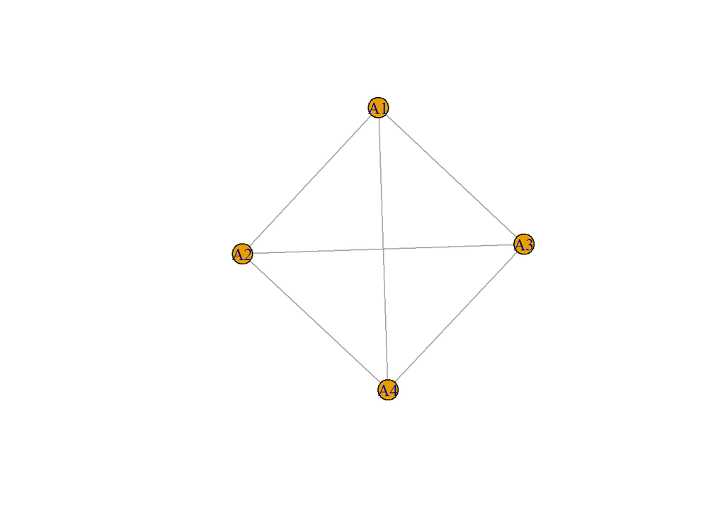

```r
g4A <- my.tri4("A")
plot(g4A$g) # 正四面体
```

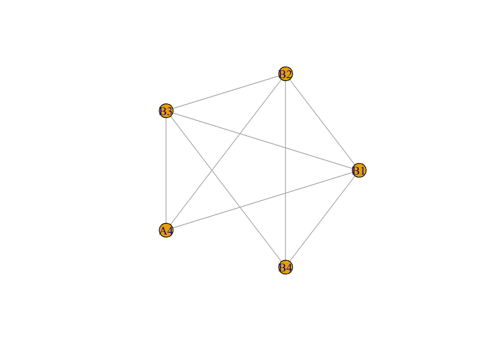

```r
g4B <- my.tri4("B")
# 正四面体の張り合わせ
gx <- my.paste.g(g4A,g4B,1,1)

# 張り合わせオブジェクト
plot(gx$g,layout=layout_in_circle)
```

```r
# 張り合わせオブジェクトの６つの三角形
gx$faces
```

```
##      [,1] [,2] [,3]
## [1,] "B1" "B3" "A4"
## [2,] "B1" "A4" "B2"
## [3,] "B2" "A4" "B3"
## [4,] "B4" "B3" "B1"
## [5,] "B2" "B4" "B1"
## [6,] "B3" "B4" "B2"
```

双対グラフの各面を時計回りに回るときのエッジ接続行列は置換行列

反時計回りに回るときのエッジ接続行列も置換行列

次数３の斉次グラフなので、このふたつの置換行列の和はゼータ関数を構成するWE行列。

反時計回り置換行列は、時計回り置換行列を転置し、それについて、エッジペアを定める行列Pでサンドイッチ変換することで得られる。

また、時計回り置換行列と反時計回り置換行列とを、行にのみP処理したもの、列にのみP処理したもの、行と列とにP処理したものとを加算したとき、3k x 3k行列には、双対グラフの頂点に関して、対角成分以外を１とする行列があらわれる。

したがって、

時計回りの置換行列とPとですべてが決まる。

また、3k x 3k にした行列の重複パターンに、形の情報が収まっている可能性がある。

```r
W.clock <- matrix(0,18,18)
W.clock[1,2] <- W.clock[2,3] <- W.clock[3,1] <- W.clock[4,5] <- W.clock[5,6] <- W.clock[6,11] <- W.clock[7,8] <- W.clock[8,14] <- W.clock[9,16] <- W.clock[10,9] <- W.clock[11,4] <- W.clock[12,15] <- W.clock[13,10] <- W.clock[14,7] <- W.clock[15,17] <- W.clock[16,13] <- W.clock[17,18] <- W.clock[18,12] <- 1
apply(W.clock,1,sum)
```

```
##  [1] 1 1 1 1 1 1 1 1 1 1 1 1 1 1 1 1 1 1
```

```r
apply(W.clock,2,sum)
```

```
##  [1] 1 1 1 1 1 1 1 1 1 1 1 1 1 1 1 1 1 1
```

```r
P <- diag(rep(1,18))
P <- P[,c(10:18,1:9)]
P
```

```
##       [,1] [,2] [,3] [,4] [,5] [,6] [,7] [,8] [,9] [,10] [,11] [,12] [,13]
##  [1,]    0    0    0    0    0    0    0    0    0     1     0     0     0
##  [2,]    0    0    0    0    0    0    0    0    0     0     1     0     0
##  [3,]    0    0    0    0    0    0    0    0    0     0     0     1     0
##  [4,]    0    0    0    0    0    0    0    0    0     0     0     0     1
##  [5,]    0    0    0    0    0    0    0    0    0     0     0     0     0
##  [6,]    0    0    0    0    0    0    0    0    0     0     0     0     0
##  [7,]    0    0    0    0    0    0    0    0    0     0     0     0     0
##  [8,]    0    0    0    0    0    0    0    0    0     0     0     0     0
##  [9,]    0    0    0    0    0    0    0    0    0     0     0     0     0
## [10,]    1    0    0    0    0    0    0    0    0     0     0     0     0
## [11,]    0    1    0    0    0    0    0    0    0     0     0     0     0
## [12,]    0    0    1    0    0    0    0    0    0     0     0     0     0
## [13,]    0    0    0    1    0    0    0    0    0     0     0     0     0
## [14,]    0    0    0    0    1    0    0    0    0     0     0     0     0
```

[output cut: 23 more lines]

```r
W.counter <- P %*% t(W.clock) %*% P
```

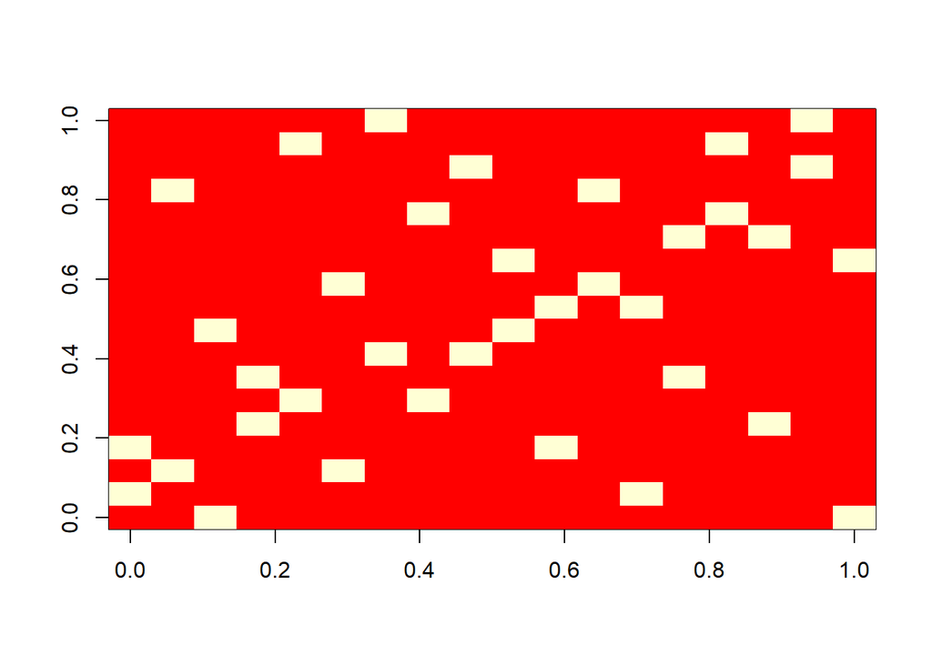

```r
We <- W.clock + W.counter
image(We)
```

```r
range(W.clock - t(P%*% W.counter %*%P))
```

```
## [1] 0 0
```

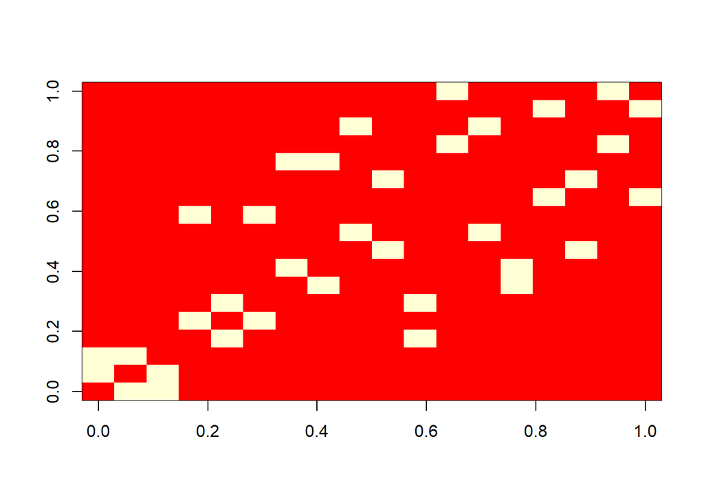

```r
We. <- W.clock + P %*% W.counter %*% P
image(We.)
```

```r
range(We.-t(We.))
```

```
## [1] 0 0
```

```r
Vs <- list()
Vs[[1]] <- c(1,2,3)
Vs[[2]] <- c(4,5,6,11)
Vs[[3]] <- c(7,8,14)
Vs[[4]] <- c(10,9,16,13)
Vs[[5]] <- c(18,12,15,17)
```

```r
for(i in 1:length(Vs)){
  print(We[Vs[[i]],Vs[[i]]])
}
```

```
##      [,1] [,2] [,3]
## [1,]    0    1    0
## [2,]    0    0    1
## [3,]    1    0    0
##      [,1] [,2] [,3] [,4]
## [1,]    0    1    0    0
## [2,]    0    0    1    0
## [3,]    0    0    0    1
## [4,]    1    0    0    0
##      [,1] [,2] [,3]
## [1,]    0    1    0
## [2,]    0    0    1
## [3,]    1    0    0
##      [,1] [,2] [,3] [,4]
## [1,]    0    1    0    0
## [2,]    0    0    1    0
## [3,]    0    0    0    1
## [4,]    1    0    0    0
##      [,1] [,2] [,3] [,4]
## [1,]    0    1    0    0
## [2,]    0    0    1    0
## [3,]    0    0    0    1
## [4,]    1    0    0    0
```

```r
Vs2 <- list()
Vs2[[1]] <- c(1,2,4)
Vs2[[2]] <- c(4,5,7)
Vs2[[3]] <- c(7,8,9)
Vs2[[4]] <- c(5,6,8)
Vs2[[5]] <- c(1,3,9)
Vs2[[6]] <- c(2,3,6)
for(i in 1:length(Vs2)){
  #Vs2[[i]] <- c(Vs2[[i]],Vs2[[i]]+9)
}
```

```r
We.. <- W.clock + P %*% W.clock %*% P + W.counter + P %*% W.counter %*% P + P %*% W.clock + P %*% W.counter + W.clock %*% P + W.counter %*% P

for(i in 1:length(Vs2)){
  print(We..[Vs2[[i]],Vs2[[i]]])
}
```

```
##      [,1] [,2] [,3]
## [1,]    0    1    1
## [2,]    1    0    1
## [3,]    1    1    0
##      [,1] [,2] [,3]
## [1,]    0    1    1
## [2,]    1    0    1
## [3,]    1    1    0
##      [,1] [,2] [,3]
## [1,]    0    1    1
## [2,]    1    0    1
## [3,]    1    1    0
##      [,1] [,2] [,3]
## [1,]    0    1    1
## [2,]    1    0    1
## [3,]    1    1    0
##      [,1] [,2] [,3]
## [1,]    0    1    1
## [2,]    1    0    1
## [3,]    1    1    0
##      [,1] [,2] [,3]
## [1,]    0    1    1
## [2,]    1    0    1
## [3,]    1    1    0
```

```r
eigen(We.)
```

```
## eigen() decomposition
## $values
##  [1]  2.000000e+00  2.000000e+00  2.000000e+00  2.000000e+00  2.000000e+00
##  [6]  2.664535e-15  2.664535e-15  2.664535e-15  0.000000e+00  0.000000e+00
## [11]  0.000000e+00 -1.000000e+00 -1.000000e+00 -1.000000e+00 -1.000000e+00
## [16] -2.000000e+00 -2.000000e+00 -2.000000e+00
##
## $vectors
##       [,1] [,2] [,3]      [,4]      [,5]          [,6]          [,7]
##  [1,]  0.0  0.0  0.0 0.5773503 0.0000000  0.000000e+00  0.000000e+00
##  [2,]  0.0  0.0  0.0 0.5773503 0.0000000  0.000000e+00  0.000000e+00
##  [3,]  0.0  0.0  0.0 0.5773503 0.0000000  0.000000e+00  0.000000e+00
##  [4,]  0.0  0.0  0.5 0.0000000 0.0000000  0.000000e+00  7.071068e-01
##  [5,]  0.0  0.0  0.5 0.0000000 0.0000000  0.000000e+00  3.925231e-16
##  [6,]  0.0  0.0  0.5 0.0000000 0.0000000  0.000000e+00 -7.071068e-01
```

[output cut: 50 more lines]

この三角メッシュグラフの双対グラフの辺接続行列を作ることにする。

```r
Fs <- gx$faces
my.edgepair <- function(g){
  el <- get.edgelist(g)
  el2 <- cbind(el[,2],el[,1])
  elA <- apply(el,1,paste,collapse="")
  elB <- apply(el2,1,paste,collapse="")
  return(rbind(cbind(elA,elB),cbind(elB,elA)))
}
my.edgepair(gx$g)
```

```
##       elA    elB
##  [1,] "B1B2" "B2B1"
##  [2,] "B1B3" "B3B1"
##  [3,] "B1A4" "A4B1"
##  [4,] "B2B3" "B3B2"
##  [5,] "B3A4" "A4B3"
##  [6,] "B2A4" "A4B2"
##  [7,] "B1B4" "B4B1"
##  [8,] "B3B4" "B4B3"
##  [9,] "B2B4" "B4B2"
## [10,] "B2B1" "B1B2"
## [11,] "B3B1" "B1B3"
## [12,] "A4B1" "B1A4"
## [13,] "B3B2" "B2B3"
## [14,] "A4B3" "B3A4"
## [15,] "A4B2" "B2A4"
## [16,] "B4B1" "B1B4"
## [17,] "B4B3" "B3B4"
## [18,] "B4B2" "B2B4"
```

```r
my.Edge.Connection <- function(gx){
  el.pair <- my.edgepair(gx$g)
  Fs <- gx$faces

  el1 <- apply(Fs[,1:2],1,paste,collapse="")
  el2 <- apply(Fs[,2:3],1,paste,collapse="")
  el3 <- apply(Fs[,c(3,1)],1,paste,collapse="")

  el <- rbind(cbind(el1,el2),cbind(el2,el3),cbind(el3,el1),cbind(el2,el1),cbind(el3,el2),cbind(el1,el3))

  G <- graph.edgelist(el)
  ord1 <- order(G[]@Dimnames[[1]])
  W.clock <- G[ord1,ord1]

  tmp.g <- graph.edgelist(el.pair,directed=TRUE)
  P <- tmp.g[]
  ord2 <- order(P@Dimnames[[1]])
  P <- P[ord2,ord2]

  Fs <- Fs[,3:1]

  el1 <- apply(Fs[,1:2],1,paste,collapse="")
  el2 <- apply(Fs[,2:3],1,paste,collapse="")
  el3 <- apply(Fs[,c(3,1)],1,paste,collapse="")

  el <- rbind(cbind(el1,el2),cbind(el2,el3),cbind(el3,el1))

  G.counter <- graph.edgelist(el)
  ord.counter1 <- order(G.counter[]@Dimnames[[1]])
  W.counter <- G.counter[ord.counter1,ord.counter1]
  return(list(g.clock=G,g.counter=G.counter,W.clock=W.clock,W.counter=W.counter,P=P,edge.pair=el.pair))
}
```

```r
G <- my.Edge.Connection(gx)
G$g.clock[]
```

```
## 18 x 18 sparse Matrix of class "dgCMatrix"
```

```
##    [[ suppressing 18 column names 'B1B3', 'B3A4', 'B1A4' ... ]]
```

```
##
## B1B3 . 1 . . . . . . . . . . 1 . . . . .
## B3A4 1 . . . . . . . . . . . 1 . . . . .
## B1A4 . . . 1 . . . . . . . . . 1 . . . .
## A4B2 . . 1 . . . . . . . . . . 1 . . . .
## B2A4 . . . . . 1 . . . . . . . . 1 . . .
## A4B3 . . . . 1 . . . . . . . . . 1 . . .
## B4B3 . . . . . . . 1 . . . . . . . 1 . .
## B3B1 . . . . . . 1 . . . . . . . . 1 . .
## B2B4 . . . . . . . . . 1 . . . . . . 1 .
## B4B1 . . . . . . . . 1 . . . . . . . 1 .
## B3B4 . . . . . . . . . . . 1 . . . . . 1
## B4B2 . . . . . . . . . . 1 . . . . . . 1
## A4B1 1 1 . . . . . . . . . . . . . . . .
## B2B1 . . 1 1 . . . . . . . . . . . . . .
## B3B2 . . . . 1 1 . . . . . . . . . . . .
## B1B4 . . . . . . 1 1 . . . . . . . . . .
## B1B2 . . . . . . . . 1 1 . . . . . . . .
## B2B3 . . . . . . . . . . 1 1 . . . . . .
```

```r
G$g.counter[]
```

```
## 18 x 18 sparse Matrix of class "dgCMatrix"
```

```
##    [[ suppressing 18 column names 'A4B3', 'B3B1', 'B2A4' ... ]]
```

```
##
## A4B3 . 1 . . . . . . . . . . . . . . . .
## B3B1 . . . . . . . . . . . . 1 . . . . .
## B2A4 . . . 1 . . . . . . . . . . . . . .
## A4B1 . . . . . . . . . . . . . 1 . . . .
## B3A4 . . . . . 1 . . . . . . . . . . . .
## A4B2 . . . . . . . . . . . . . . 1 . . .
## B1B3 . . . . . . . 1 . . . . . . . . . .
## B3B4 . . . . . . . . . . . . . . . 1 . .
## B1B4 . . . . . . . . . 1 . . . . . . . .
## B4B2 . . . . . . . . . . . . . . . . 1 .
## B2B4 . . . . . . . . . . . 1 . . . . . .
## B4B3 . . . . . . . . . . . . . . . . . 1
## B1A4 1 . . . . . . . . . . . . . . . . .
## B1B2 . . 1 . . . . . . . . . . . . . . .
## B2B3 . . . . 1 . . . . . . . . . . . . .
## B4B1 . . . . . . 1 . . . . . . . . . . .
## B2B1 . . . . . . . . 1 . . . . . . . . .
## B3B2 . . . . . . . . . . 1 . . . . . . .
```

```r
G$W.clock
```

```
## 18 x 18 sparse Matrix of class "dgCMatrix"
```

```
##    [[ suppressing 18 column names 'A4B1', 'A4B2', 'A4B3' ... ]]
```

```
##
## A4B1 . . . . . 1 . . . . . 1 . . . . . .
## A4B2 . . . 1 . . . . 1 . . . . . . . . .
## A4B3 . . . . . . . 1 . . . . . 1 . . . .
## B1A4 . 1 . . . . . . 1 . . . . . . . . .
## B1B2 . . . . . . . . . . 1 . . . . 1 . .
## B1B3 1 . . . . . . . . . . 1 . . . . . .
## B1B4 . . . . . . . . . . . . 1 . . . . 1
## B2A4 . . 1 . . . . . . . . . . 1 . . . .
## B2B1 . 1 . 1 . . . . . . . . . . . . . .
## B2B3 . . . . . . . . . . . . . . 1 . 1 .
## B2B4 . . . . 1 . . . . . . . . . . 1 . .
## B3A4 1 . . . . 1 . . . . . . . . . . . .
## B3B1 . . . . . . 1 . . . . . . . . . . 1
## B3B2 . . 1 . . . . 1 . . . . . . . . . .
## B3B4 . . . . . . . . . 1 . . . . . . 1 .
## B4B1 . . . . 1 . . . . . 1 . . . . . . .
## B4B2 . . . . . . . . . 1 . . . . 1 . . .
## B4B3 . . . . . . 1 . . . . . 1 . . . . .
```

```r
G$W.counter
```

```
## 18 x 18 sparse Matrix of class "dgCMatrix"
```

```
##    [[ suppressing 18 column names 'A4B1', 'A4B2', 'A4B3' ... ]]
```

```
##
## A4B1 . . . . 1 . . . . . . . . . . . . .
## A4B2 . . . . . . . . . 1 . . . . . . . .
## A4B3 . . . . . . . . . . . . 1 . . . . .
## B1A4 . . 1 . . . . . . . . . . . . . . .
## B1B2 . . . . . . . 1 . . . . . . . . . .
## B1B3 . . . . . . . . . . . . . . 1 . . .
## B1B4 . . . . . . . . . . . . . . . . 1 .
## B2A4 1 . . . . . . . . . . . . . . . . .
## B2B1 . . . . . . 1 . . . . . . . . . . .
## B2B3 . . . . . . . . . . . 1 . . . . . .
## B2B4 . . . . . . . . . . . . . . . . . 1
## B3A4 . 1 . . . . . . . . . . . . . . . .
## B3B1 . . . 1 . . . . . . . . . . . . . .
## B3B2 . . . . . . . . . . 1 . . . . . . .
## B3B4 . . . . . . . . . . . . . . . 1 . .
## B4B1 . . . . . 1 . . . . . . . . . . . .
## B4B2 . . . . . . . . 1 . . . . . . . . .
## B4B3 . . . . . . . . . . . . . 1 . . . .
```

```r
G$P
```

```
## 18 x 18 sparse Matrix of class "dgCMatrix"
```

```
##    [[ suppressing 18 column names 'A4B1', 'A4B2', 'A4B3' ... ]]
```

```
##
## A4B1 . . . 1 . . . . . . . . . . . . . .
## A4B2 . . . . . . . 1 . . . . . . . . . .
## A4B3 . . . . . . . . . . . 1 . . . . . .
## B1A4 1 . . . . . . . . . . . . . . . . .
## B1B2 . . . . . . . . 1 . . . . . . . . .
## B1B3 . . . . . . . . . . . . 1 . . . . .
## B1B4 . . . . . . . . . . . . . . . 1 . .
## B2A4 . 1 . . . . . . . . . . . . . . . .
## B2B1 . . . . 1 . . . . . . . . . . . . .
## B2B3 . . . . . . . . . . . . . 1 . . . .
## B2B4 . . . . . . . . . . . . . . . . 1 .
## B3A4 . . 1 . . . . . . . . . . . . . . .
## B3B1 . . . . . 1 . . . . . . . . . . . .
## B3B2 . . . . . . . . . 1 . . . . . . . .
## B3B4 . . . . . . . . . . . . . . . . . 1
## B4B1 . . . . . . 1 . . . . . . . . . . .
## B4B2 . . . . . . . . . . 1 . . . . . . .
## B4B3 . . . . . . . . . . . . . . 1 . . .
```

```r
G$edge.pair
```

```
##       elA    elB
##  [1,] "B1B2" "B2B1"
##  [2,] "B1B3" "B3B1"
##  [3,] "B1A4" "A4B1"
##  [4,] "B2B3" "B3B2"
##  [5,] "B3A4" "A4B3"
##  [6,] "B2A4" "A4B2"
##  [7,] "B1B4" "B4B1"
##  [8,] "B3B4" "B4B3"
##  [9,] "B2B4" "B4B2"
## [10,] "B2B1" "B1B2"
## [11,] "B3B1" "B1B3"
## [12,] "A4B1" "B1A4"
## [13,] "B3B2" "B2B3"
## [14,] "A4B3" "B3A4"
## [15,] "A4B2" "B2A4"
## [16,] "B4B1" "B1B4"
## [17,] "B4B3" "B3B4"
## [18,] "B4B2" "B2B4"
```

```r
G.counter.switch <- G$P %*% G$W.counter %*% G$P
G.counter.switch
```

```
## 18 x 18 sparse Matrix of class "dgCMatrix"
```

```
##    [[ suppressing 18 column names 'A4B1', 'A4B2', 'A4B3' ... ]]
```

```
##
## A4B1 . . . . . . . . . . . 1 . . . . . .
## A4B2 . . . 1 . . . . . . . . . . . . . .
## A4B3 . . . . . . . 1 . . . . . . . . . .
## B1A4 . . . . . . . . 1 . . . . . . . . .
## B1B2 . . . . . . . . . . . . . . . 1 . .
## B1B3 1 . . . . . . . . . . . . . . . . .
## B1B4 . . . . . . . . . . . . 1 . . . . .
## B2A4 . . . . . . . . . . . . . 1 . . . .
## B2B1 . 1 . . . . . . . . . . . . . . . .
## B2B3 . . . . . . . . . . . . . . . . 1 .
## B2B4 . . . . 1 . . . . . . . . . . . . .
## B3A4 . . . . . 1 . . . . . . . . . . . .
## B3B1 . . . . . . . . . . . . . . . . . 1
## B3B2 . . 1 . . . . . . . . . . . . . . .
## B3B4 . . . . . . . . . 1 . . . . . . . .
## B4B1 . . . . . . . . . . 1 . . . . . . .
## B4B2 . . . . . . . . . . . . . . 1 . . .
## B4B3 . . . . . . 1 . . . . . . . . . . .
```

```r
We <- G$W.clock + G.counter.switch
range(as.matrix(We) - t(as.matrix(We)))
```

```
## [1] -1  1
```

```r
apply(We,1,sum)
```

```
## A4B1 A4B2 A4B3 B1A4 B1B2 B1B3 B1B4 B2A4 B2B1 B2B3 B2B4 B3A4 B3B1 B3B2 B3B4
##    3    3    3    3    3    3    3    3    3    3    3    3    3    3    3
## B4B1 B4B2 B4B3
##    3    3    3
```

```r
apply(We,2,sum)
```

```
## A4B1 A4B2 A4B3 B1A4 B1B2 B1B3 B1B4 B2A4 B2B1 B2B3 B2B4 B3A4 B3B1 B3B2 B3B4
##    3    3    3    3    3    3    3    3    3    3    3    3    3    3    3
## B4B1 B4B2 B4B3
##    3    3    3
```